# Risk Factor Analysis

## Outcome Variable

**Outcome Variable:** whz

## Predictor Variables

**Intervention Variable:** trth2o

**Adjustment Set:**

- arm
- sex
- W_mage
- meducyrs
- feducyrs
- hhwealth_quart
- hfoodsec
- W_mhtcm
- W_mwtkg
- W_mbmi
- W_nrooms
- W_nhh
- W_nchldlt5
- brthmon
- cleanck
- impfloor
- impsan
- safeh20
- delta_meducyrs
- delta_feducyrs
- delta_hhwealth_quart
- delta_hfoodsec
- delta_W_mhtcm
- delta_W_mwtkg
- delta_W_mbmi
- delta_W_nrooms
- delta_W_nhh
- delta_W_nchldlt5
- delta_brthmon
- delta_cleanck
- delta_impfloor
- delta_impsan
- delta_safeh20

## Stratifying Variables

The analysis was stratified on these variable(s):

- agecat
- studyid
- country

## Data Summary

| agecat | studyid | country | trth2o | n_cell | n | outcome_variable |
| --- | --- | --- | --- | --- | --- | --- |
| Birth | ki0047075b-MAL-ED | BANGLADESH | 1 | 110 | 112 | whz |
| Birth | ki0047075b-MAL-ED | BANGLADESH | 0 | 2 | 112 | whz |
| Birth | ki0047075b-MAL-ED | BRAZIL | 1 | 3 | 20 | whz |
| Birth | ki0047075b-MAL-ED | BRAZIL | 0 | 17 | 20 | whz |
| Birth | ki0047075b-MAL-ED | INDIA | 1 | 0 | 1 | whz |
| Birth | ki0047075b-MAL-ED | INDIA | 0 | 1 | 1 | whz |
| Birth | ki0047075b-MAL-ED | NEPAL | 1 | 7 | 9 | whz |
| Birth | ki0047075b-MAL-ED | NEPAL | 0 | 2 | 9 | whz |
| Birth | ki0047075b-MAL-ED | PERU | 1 | 28 | 36 | whz |
| Birth | ki0047075b-MAL-ED | PERU | 0 | 8 | 36 | whz |
| Birth | ki0047075b-MAL-ED | SOUTH AFRICA | 1 | 1 | 5 | whz |
| Birth | ki0047075b-MAL-ED | SOUTH AFRICA | 0 | 4 | 5 | whz |
| Birth | ki0047075b-MAL-ED | TANZANIA, UNITED REPUBLIC OF | 1 | 4 | 21 | whz |
| Birth | ki0047075b-MAL-ED | TANZANIA, UNITED REPUBLIC OF | 0 | 17 | 21 | whz |
| Birth | ki1000108-CMC-V-BCS-2002 | INDIA | 1 | 24 | 24 | whz |
| Birth | ki1000108-CMC-V-BCS-2002 | INDIA | 0 | 0 | 24 | whz |
| Birth | ki1000108-IRC | INDIA | 1 | 105 | 105 | whz |
| Birth | ki1000108-IRC | INDIA | 0 | 0 | 105 | whz |
| Birth | ki1017093b-PROVIDE | BANGLADESH | 1 | 11 | 532 | whz |
| Birth | ki1017093b-PROVIDE | BANGLADESH | 0 | 521 | 532 | whz |
| Birth | ki1017093c-NIH-Crypto | BANGLADESH | 1 | 397 | 707 | whz |
| Birth | ki1017093c-NIH-Crypto | BANGLADESH | 0 | 310 | 707 | whz |
| Birth | ki1113344-GMS-Nepal | NEPAL | 1 | 1 | 4 | whz |
| Birth | ki1113344-GMS-Nepal | NEPAL | 0 | 3 | 4 | whz |
| 6 months | ki0047075b-MAL-ED | BANGLADESH | 1 | 132 | 134 | whz |
| 6 months | ki0047075b-MAL-ED | BANGLADESH | 0 | 2 | 134 | whz |
| 6 months | ki0047075b-MAL-ED | BRAZIL | 1 | 13 | 103 | whz |
| 6 months | ki0047075b-MAL-ED | BRAZIL | 0 | 90 | 103 | whz |
| 6 months | ki0047075b-MAL-ED | INDIA | 1 | 4 | 9 | whz |
| 6 months | ki0047075b-MAL-ED | INDIA | 0 | 5 | 9 | whz |
| 6 months | ki0047075b-MAL-ED | NEPAL | 1 | 69 | 83 | whz |
| 6 months | ki0047075b-MAL-ED | NEPAL | 0 | 14 | 83 | whz |
| 6 months | ki0047075b-MAL-ED | PERU | 1 | 39 | 49 | whz |
| 6 months | ki0047075b-MAL-ED | PERU | 0 | 10 | 49 | whz |
| 6 months | ki0047075b-MAL-ED | SOUTH AFRICA | 1 | 2 | 12 | whz |
| 6 months | ki0047075b-MAL-ED | SOUTH AFRICA | 0 | 10 | 12 | whz |
| 6 months | ki0047075b-MAL-ED | TANZANIA, UNITED REPUBLIC OF | 1 | 6 | 42 | whz |
| 6 months | ki0047075b-MAL-ED | TANZANIA, UNITED REPUBLIC OF | 0 | 36 | 42 | whz |
| 6 months | ki1000108-CMC-V-BCS-2002 | INDIA | 1 | 120 | 120 | whz |
| 6 months | ki1000108-CMC-V-BCS-2002 | INDIA | 0 | 0 | 120 | whz |
| 6 months | ki1000108-IRC | INDIA | 1 | 121 | 121 | whz |
| 6 months | ki1000108-IRC | INDIA | 0 | 0 | 121 | whz |
| 6 months | ki1017093b-PROVIDE | BANGLADESH | 1 | 14 | 603 | whz |
| 6 months | ki1017093b-PROVIDE | BANGLADESH | 0 | 589 | 603 | whz |
| 6 months | ki1017093c-NIH-Crypto | BANGLADESH | 1 | 396 | 715 | whz |
| 6 months | ki1017093c-NIH-Crypto | BANGLADESH | 0 | 319 | 715 | whz |
| 6 months | ki1113344-GMS-Nepal | NEPAL | 1 | 1 | 4 | whz |
| 6 months | ki1113344-GMS-Nepal | NEPAL | 0 | 3 | 4 | whz |
| 24 months | ki0047075b-MAL-ED | BANGLADESH | 1 | 133 | 135 | whz |
| 24 months | ki0047075b-MAL-ED | BANGLADESH | 0 | 2 | 135 | whz |
| 24 months | ki0047075b-MAL-ED | BRAZIL | 1 | 13 | 103 | whz |
| 24 months | ki0047075b-MAL-ED | BRAZIL | 0 | 90 | 103 | whz |
| 24 months | ki0047075b-MAL-ED | INDIA | 1 | 4 | 9 | whz |
| 24 months | ki0047075b-MAL-ED | INDIA | 0 | 5 | 9 | whz |
| 24 months | ki0047075b-MAL-ED | NEPAL | 1 | 69 | 83 | whz |
| 24 months | ki0047075b-MAL-ED | NEPAL | 0 | 14 | 83 | whz |
| 24 months | ki0047075b-MAL-ED | PERU | 1 | 39 | 49 | whz |
| 24 months | ki0047075b-MAL-ED | PERU | 0 | 10 | 49 | whz |
| 24 months | ki0047075b-MAL-ED | SOUTH AFRICA | 1 | 2 | 11 | whz |
| 24 months | ki0047075b-MAL-ED | SOUTH AFRICA | 0 | 9 | 11 | whz |
| 24 months | ki0047075b-MAL-ED | TANZANIA, UNITED REPUBLIC OF | 1 | 6 | 43 | whz |
| 24 months | ki0047075b-MAL-ED | TANZANIA, UNITED REPUBLIC OF | 0 | 37 | 43 | whz |
| 24 months | ki1000108-CMC-V-BCS-2002 | INDIA | 1 | 119 | 119 | whz |
| 24 months | ki1000108-CMC-V-BCS-2002 | INDIA | 0 | 0 | 119 | whz |
| 24 months | ki1000108-IRC | INDIA | 1 | 121 | 121 | whz |
| 24 months | ki1000108-IRC | INDIA | 0 | 0 | 121 | whz |
| 24 months | ki1017093b-PROVIDE | BANGLADESH | 1 | 14 | 579 | whz |
| 24 months | ki1017093b-PROVIDE | BANGLADESH | 0 | 565 | 579 | whz |
| 24 months | ki1017093c-NIH-Crypto | BANGLADESH | 1 | 242 | 514 | whz |
| 24 months | ki1017093c-NIH-Crypto | BANGLADESH | 0 | 272 | 514 | whz |
| 24 months | ki1113344-GMS-Nepal | NEPAL | 1 | 1 | 4 | whz |
| 24 months | ki1113344-GMS-Nepal | NEPAL | 0 | 3 | 4 | whz |

The following strata were considered:

- agecat: 24 months, studyid: ki0047075b-MAL-ED, country: BANGLADESH
- agecat: 24 months, studyid: ki0047075b-MAL-ED, country: BRAZIL
- agecat: 24 months, studyid: ki0047075b-MAL-ED, country: INDIA
- agecat: 24 months, studyid: ki0047075b-MAL-ED, country: NEPAL
- agecat: 24 months, studyid: ki0047075b-MAL-ED, country: PERU
- agecat: 24 months, studyid: ki0047075b-MAL-ED, country: SOUTH AFRICA
- agecat: 24 months, studyid: ki0047075b-MAL-ED, country: TANZANIA, UNITED REPUBLIC OF
- agecat: 24 months, studyid: ki1000108-CMC-V-BCS-2002, country: INDIA
- agecat: 24 months, studyid: ki1000108-IRC, country: INDIA
- agecat: 24 months, studyid: ki1017093b-PROVIDE, country: BANGLADESH
- agecat: 24 months, studyid: ki1017093c-NIH-Crypto, country: BANGLADESH
- agecat: 24 months, studyid: ki1113344-GMS-Nepal, country: NEPAL
- agecat: 6 months, studyid: ki0047075b-MAL-ED, country: BANGLADESH
- agecat: 6 months, studyid: ki0047075b-MAL-ED, country: BRAZIL
- agecat: 6 months, studyid: ki0047075b-MAL-ED, country: INDIA
- agecat: 6 months, studyid: ki0047075b-MAL-ED, country: NEPAL
- agecat: 6 months, studyid: ki0047075b-MAL-ED, country: PERU
- agecat: 6 months, studyid: ki0047075b-MAL-ED, country: SOUTH AFRICA
- agecat: 6 months, studyid: ki0047075b-MAL-ED, country: TANZANIA, UNITED REPUBLIC OF
- agecat: 6 months, studyid: ki1000108-CMC-V-BCS-2002, country: INDIA
- agecat: 6 months, studyid: ki1000108-IRC, country: INDIA
- agecat: 6 months, studyid: ki1017093b-PROVIDE, country: BANGLADESH
- agecat: 6 months, studyid: ki1017093c-NIH-Crypto, country: BANGLADESH
- agecat: 6 months, studyid: ki1113344-GMS-Nepal, country: NEPAL
- agecat: Birth, studyid: ki0047075b-MAL-ED, country: BANGLADESH
- agecat: Birth, studyid: ki0047075b-MAL-ED, country: BRAZIL
- agecat: Birth, studyid: ki0047075b-MAL-ED, country: INDIA
- agecat: Birth, studyid: ki0047075b-MAL-ED, country: NEPAL
- agecat: Birth, studyid: ki0047075b-MAL-ED, country: PERU
- agecat: Birth, studyid: ki0047075b-MAL-ED, country: SOUTH AFRICA
- agecat: Birth, studyid: ki0047075b-MAL-ED, country: TANZANIA, UNITED REPUBLIC OF
- agecat: Birth, studyid: ki1000108-CMC-V-BCS-2002, country: INDIA
- agecat: Birth, studyid: ki1000108-IRC, country: INDIA
- agecat: Birth, studyid: ki1017093b-PROVIDE, country: BANGLADESH
- agecat: Birth, studyid: ki1017093c-NIH-Crypto, country: BANGLADESH
- agecat: Birth, studyid: ki1113344-GMS-Nepal, country: NEPAL

### Dropped Strata

Some strata were dropped due to rare outcomes:

- agecat: Birth, studyid: ki0047075b-MAL-ED, country: BANGLADESH
- agecat: Birth, studyid: ki0047075b-MAL-ED, country: BRAZIL
- agecat: Birth, studyid: ki0047075b-MAL-ED, country: INDIA
- agecat: Birth, studyid: ki0047075b-MAL-ED, country: NEPAL
- agecat: Birth, studyid: ki0047075b-MAL-ED, country: SOUTH AFRICA
- agecat: Birth, studyid: ki0047075b-MAL-ED, country: TANZANIA, UNITED REPUBLIC OF
- agecat: Birth, studyid: ki1000108-CMC-V-BCS-2002, country: INDIA
- agecat: Birth, studyid: ki1000108-IRC, country: INDIA
- agecat: Birth, studyid: ki1113344-GMS-Nepal, country: NEPAL
- agecat: 6 months, studyid: ki0047075b-MAL-ED, country: BANGLADESH
- agecat: 6 months, studyid: ki0047075b-MAL-ED, country: INDIA
- agecat: 6 months, studyid: ki0047075b-MAL-ED, country: SOUTH AFRICA
- agecat: 6 months, studyid: ki1000108-CMC-V-BCS-2002, country: INDIA
- agecat: 6 months, studyid: ki1000108-IRC, country: INDIA
- agecat: 6 months, studyid: ki1113344-GMS-Nepal, country: NEPAL
- agecat: 24 months, studyid: ki0047075b-MAL-ED, country: BANGLADESH
- agecat: 24 months, studyid: ki0047075b-MAL-ED, country: INDIA
- agecat: 24 months, studyid: ki0047075b-MAL-ED, country: SOUTH AFRICA
- agecat: 24 months, studyid: ki1000108-CMC-V-BCS-2002, country: INDIA
- agecat: 24 months, studyid: ki1000108-IRC, country: INDIA
- agecat: 24 months, studyid: ki1113344-GMS-Nepal, country: NEPAL

## Methods Detail

We’re interested in the causal parameters $E[Y_a]$ for all values of $a \in \mathcal{A}$. These parameters represent the mean outcome if, possibly contrary to fact, we intervened to set all units to have $A=a$. Under the randomization and positivity assumptions, these are identified by the statistical parameters $\psi_a=E_W[E_{Y|A,W}(Y|A=a,W)]$. In addition, we’re interested in the mean of $Y$, $E[Y]$ under no intervention (the observed mean). We will estimate these parameters by using SuperLearner to fit the relevant likelihood factors – $E_{Y|A,W}(Y|A=a,W)$ and $p(A=a|W)$, and then updating our likelihood fit using a joint TMLE.

For unadjusted analyses ($W=\{\}$), initial likelihoods were estimated using Lrnr_glm to estimate the simple $E(Y|A)$ and Lrnr_mean to estimate $p(A)$. For adjusted analyses, a small library containing Lrnr_glmnet, Lrnr_xgboost, and Lrnr_mean was used.

Having estimated these parameters, we will then use the delta method to estimate relative risks and attributable risks relative to a prespecified baseline level of $A$.

# Results Detail

## Results Plots

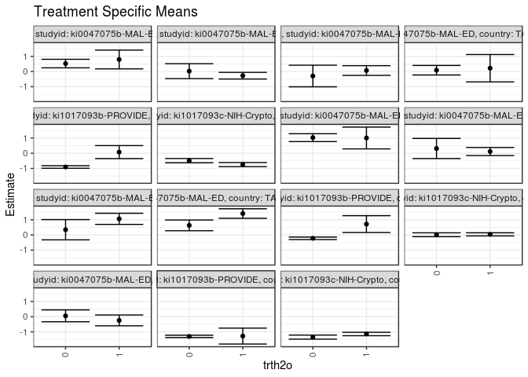

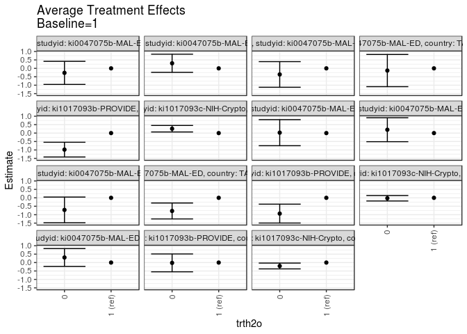

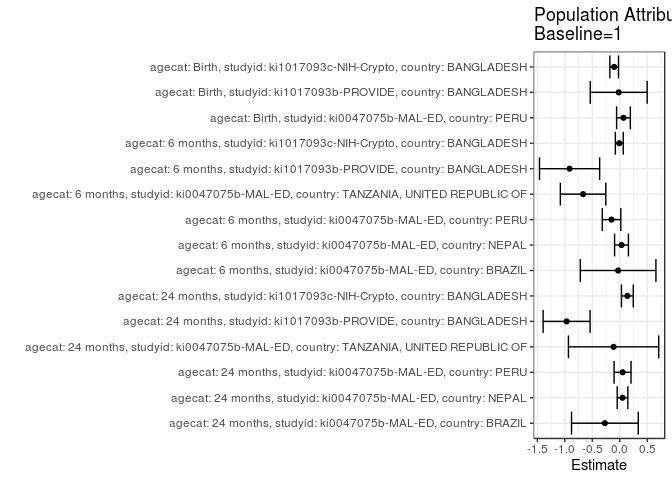

## Results Table

### Parameter: TSM

| agecat | studyid | country | intervention_level | baseline_level | estimate | ci_lower | ci_upper |
| --- | --- | --- | --- | --- | --- | --- | --- |
| Birth | ki0047075b-MAL-ED | PERU | 1 | NA | -0.2460714 | -0.6028599 | 0.1107170 |
| Birth | ki0047075b-MAL-ED | PERU | 0 | NA | 0.0550000 | -0.3367180 | 0.4467180 |
| Birth | ki1017093b-PROVIDE | BANGLADESH | 1 | NA | -1.2789781 | -1.8034837 | -0.7544725 |
| Birth | ki1017093b-PROVIDE | BANGLADESH | 0 | NA | -1.2986667 | -1.3763824 | -1.2209509 |
| Birth | ki1017093c-NIH-Crypto | BANGLADESH | 1 | NA | -1.1416796 | -1.2535888 | -1.0297703 |
| Birth | ki1017093c-NIH-Crypto | BANGLADESH | 0 | NA | -1.3451703 | -1.4772798 | -1.2130608 |
| 6 months | ki0047075b-MAL-ED | BRAZIL | 1 | NA | 1.0037168 | 0.2863196 | 1.7211141 |
| 6 months | ki0047075b-MAL-ED | BRAZIL | 0 | NA | 1.0280699 | 0.7695914 | 1.2865484 |
| 6 months | ki0047075b-MAL-ED | NEPAL | 1 | NA | 0.1137477 | -0.1511421 | 0.3786375 |
| 6 months | ki0047075b-MAL-ED | NEPAL | 0 | NA | 0.3117871 | -0.3504416 | 0.9740157 |
| 6 months | ki0047075b-MAL-ED | PERU | 1 | NA | 1.0612277 | 0.6949898 | 1.4274656 |
| 6 months | ki0047075b-MAL-ED | PERU | 0 | NA | 0.3442375 | -0.3220622 | 1.0105373 |
| 6 months | ki0047075b-MAL-ED | TANZANIA, UNITED REPUBLIC OF | 1 | NA | 1.4100000 | 1.0960519 | 1.7239481 |
| 6 months | ki0047075b-MAL-ED | TANZANIA, UNITED REPUBLIC OF | 0 | NA | 0.6305093 | 0.2775495 | 0.9834691 |
| 6 months | ki1017093b-PROVIDE | BANGLADESH | 1 | NA | 0.7145565 | 0.1609733 | 1.2681397 |
| 6 months | ki1017093b-PROVIDE | BANGLADESH | 0 | NA | -0.2207666 | -0.3038710 | -0.1376622 |
| 6 months | ki1017093c-NIH-Crypto | BANGLADESH | 1 | NA | 0.0387781 | -0.0634387 | 0.1409949 |
| 6 months | ki1017093c-NIH-Crypto | BANGLADESH | 0 | NA | 0.0127569 | -0.1138561 | 0.1393699 |
| 24 months | ki0047075b-MAL-ED | BRAZIL | 1 | NA | 0.7915384 | 0.1725519 | 1.4105250 |
| 24 months | ki0047075b-MAL-ED | BRAZIL | 0 | NA | 0.5230666 | 0.2417018 | 0.8044313 |
| 24 months | ki0047075b-MAL-ED | NEPAL | 1 | NA | -0.2759013 | -0.4936839 | -0.0581188 |
| 24 months | ki0047075b-MAL-ED | NEPAL | 0 | NA | 0.0238324 | -0.4679350 | 0.5155999 |
| 24 months | ki0047075b-MAL-ED | PERU | 1 | NA | 0.0645531 | -0.2541327 | 0.3832389 |
| 24 months | ki0047075b-MAL-ED | PERU | 0 | NA | -0.2966918 | -1.0070223 | 0.4136386 |
| 24 months | ki0047075b-MAL-ED | TANZANIA, UNITED REPUBLIC OF | 1 | NA | 0.2166667 | -0.6845675 | 1.1179009 |
| 24 months | ki0047075b-MAL-ED | TANZANIA, UNITED REPUBLIC OF | 0 | NA | 0.0854054 | -0.2281139 | 0.3989247 |
| 24 months | ki1017093b-PROVIDE | BANGLADESH | 1 | NA | 0.0750631 | -0.3533898 | 0.5035160 |
| 24 months | ki1017093b-PROVIDE | BANGLADESH | 0 | NA | -0.9051908 | -0.9891398 | -0.8212418 |
| 24 months | ki1017093c-NIH-Crypto | BANGLADESH | 1 | NA | -0.7478448 | -0.8820095 | -0.6136801 |
| 24 months | ki1017093c-NIH-Crypto | BANGLADESH | 0 | NA | -0.4889482 | -0.6299838 | -0.3479126 |

### Parameter: E(Y)

| agecat | studyid | country | intervention_level | baseline_level | estimate | ci_lower | ci_upper |
| --- | --- | --- | --- | --- | --- | --- | --- |
| Birth | ki0047075b-MAL-ED | PERU | NA | NA | -0.1791667 | -0.4729428 | 0.1146094 |
| Birth | ki1017093b-PROVIDE | BANGLADESH | NA | NA | -1.2984586 | -1.3752758 | -1.2216415 |
| Birth | ki1017093c-NIH-Crypto | BANGLADESH | NA | NA | -1.2441513 | -1.3281130 | -1.1601897 |
| 6 months | ki0047075b-MAL-ED | BRAZIL | NA | NA | 0.9731715 | 0.7347562 | 1.2115869 |
| 6 months | ki0047075b-MAL-ED | NEPAL | NA | NA | 0.1447189 | -0.1029021 | 0.3923399 |
| 6 months | ki0047075b-MAL-ED | PERU | NA | NA | 0.9109184 | 0.5934529 | 1.2283839 |
| 6 months | ki0047075b-MAL-ED | TANZANIA, UNITED REPUBLIC OF | NA | NA | 0.7418651 | 0.4248303 | 1.0588998 |
| 6 months | ki1017093b-PROVIDE | BANGLADESH | NA | NA | -0.1990907 | -0.2817968 | -0.1163845 |
| 6 months | ki1017093c-NIH-Crypto | BANGLADESH | NA | NA | 0.0297622 | -0.0491685 | 0.1086930 |
| 24 months | ki0047075b-MAL-ED | BRAZIL | NA | NA | 0.5203560 | 0.2632846 | 0.7774274 |
| 24 months | ki0047075b-MAL-ED | NEPAL | NA | NA | -0.2262651 | -0.4277663 | -0.0247638 |
| 24 months | ki0047075b-MAL-ED | PERU | NA | NA | 0.1148299 | -0.1831101 | 0.4127700 |
| 24 months | ki0047075b-MAL-ED | TANZANIA, UNITED REPUBLIC OF | NA | NA | 0.1037209 | -0.1942394 | 0.4016813 |
| 24 months | ki1017093b-PROVIDE | BANGLADESH | NA | NA | -0.8928670 | -0.9755153 | -0.8102187 |
| 24 months | ki1017093c-NIH-Crypto | BANGLADESH | NA | NA | -0.6103502 | -0.7050157 | -0.5156847 |

### Parameter: ATE

| agecat | studyid | country | intervention_level | baseline_level | estimate | ci_lower | ci_upper |
| --- | --- | --- | --- | --- | --- | --- | --- |
| Birth | ki0047075b-MAL-ED | PERU | 1 | 1 | 0.0000000 | 0.0000000 | 0.0000000 |
| Birth | ki0047075b-MAL-ED | PERU | 0 | 1 | 0.3010714 | -0.2287785 | 0.8309214 |
| Birth | ki1017093b-PROVIDE | BANGLADESH | 1 | 1 | 0.0000000 | 0.0000000 | 0.0000000 |
| Birth | ki1017093b-PROVIDE | BANGLADESH | 0 | 1 | -0.0196885 | -0.5495564 | 0.5101793 |
| Birth | ki1017093c-NIH-Crypto | BANGLADESH | 1 | 1 | 0.0000000 | 0.0000000 | 0.0000000 |
| Birth | ki1017093c-NIH-Crypto | BANGLADESH | 0 | 1 | -0.2034907 | -0.3764029 | -0.0305786 |
| 6 months | ki0047075b-MAL-ED | BRAZIL | 1 | 1 | 0.0000000 | 0.0000000 | 0.0000000 |
| 6 months | ki0047075b-MAL-ED | BRAZIL | 0 | 1 | 0.0243530 | -0.7488056 | 0.7975117 |
| 6 months | ki0047075b-MAL-ED | NEPAL | 1 | 1 | 0.0000000 | 0.0000000 | 0.0000000 |
| 6 months | ki0047075b-MAL-ED | NEPAL | 0 | 1 | 0.1980393 | -0.5115923 | 0.9076710 |
| 6 months | ki0047075b-MAL-ED | PERU | 1 | 1 | 0.0000000 | 0.0000000 | 0.0000000 |
| 6 months | ki0047075b-MAL-ED | PERU | 0 | 1 | -0.7169902 | -1.4791636 | 0.0451833 |
| 6 months | ki0047075b-MAL-ED | TANZANIA, UNITED REPUBLIC OF | 1 | 1 | 0.0000000 | 0.0000000 | 0.0000000 |
| 6 months | ki0047075b-MAL-ED | TANZANIA, UNITED REPUBLIC OF | 0 | 1 | -0.7794907 | -1.2518720 | -0.3071095 |
| 6 months | ki1017093b-PROVIDE | BANGLADESH | 1 | 1 | 0.0000000 | 0.0000000 | 0.0000000 |
| 6 months | ki1017093b-PROVIDE | BANGLADESH | 0 | 1 | -0.9353231 | -1.4947645 | -0.3758816 |
| 6 months | ki1017093c-NIH-Crypto | BANGLADESH | 1 | 1 | 0.0000000 | 0.0000000 | 0.0000000 |
| 6 months | ki1017093c-NIH-Crypto | BANGLADESH | 0 | 1 | -0.0260212 | -0.1882495 | 0.1362072 |
| 24 months | ki0047075b-MAL-ED | BRAZIL | 1 | 1 | 0.0000000 | 0.0000000 | 0.0000000 |
| 24 months | ki0047075b-MAL-ED | BRAZIL | 0 | 1 | -0.2684718 | -0.9526655 | 0.4157218 |
| 24 months | ki0047075b-MAL-ED | NEPAL | 1 | 1 | 0.0000000 | 0.0000000 | 0.0000000 |
| 24 months | ki0047075b-MAL-ED | NEPAL | 0 | 1 | 0.2997338 | -0.2383700 | 0.8378375 |
| 24 months | ki0047075b-MAL-ED | PERU | 1 | 1 | 0.0000000 | 0.0000000 | 0.0000000 |
| 24 months | ki0047075b-MAL-ED | PERU | 0 | 1 | -0.3612449 | -1.1214842 | 0.3989944 |
| 24 months | ki0047075b-MAL-ED | TANZANIA, UNITED REPUBLIC OF | 1 | 1 | 0.0000000 | 0.0000000 | 0.0000000 |
| 24 months | ki0047075b-MAL-ED | TANZANIA, UNITED REPUBLIC OF | 0 | 1 | -0.1312613 | -1.0854716 | 0.8229491 |
| 24 months | ki1017093b-PROVIDE | BANGLADESH | 1 | 1 | 0.0000000 | 0.0000000 | 0.0000000 |
| 24 months | ki1017093b-PROVIDE | BANGLADESH | 0 | 1 | -0.9802539 | -1.4171113 | -0.5433966 |
| 24 months | ki1017093c-NIH-Crypto | BANGLADESH | 1 | 1 | 0.0000000 | 0.0000000 | 0.0000000 |
| 24 months | ki1017093c-NIH-Crypto | BANGLADESH | 0 | 1 | 0.2588966 | 0.0651299 | 0.4526633 |

### Parameter: PAR

| agecat | studyid | country | intervention_level | baseline_level | estimate | ci_lower | ci_upper |
| --- | --- | --- | --- | --- | --- | --- | --- |
| Birth | ki0047075b-MAL-ED | PERU | 1 | NA | 0.0669048 | -0.0579283 | 0.1917378 |
| Birth | ki1017093b-PROVIDE | BANGLADESH | 1 | NA | -0.0194805 | -0.5369378 | 0.4979768 |
| Birth | ki1017093c-NIH-Crypto | BANGLADESH | 1 | NA | -0.1024718 | -0.1807458 | -0.0241977 |
| 6 months | ki0047075b-MAL-ED | BRAZIL | 1 | NA | -0.0305453 | -0.7181480 | 0.6570574 |
| 6 months | ki0047075b-MAL-ED | NEPAL | 1 | NA | 0.0309712 | -0.0950187 | 0.1569610 |
| 6 months | ki0047075b-MAL-ED | PERU | 1 | NA | -0.1503093 | -0.3188510 | 0.0182323 |
| 6 months | ki0047075b-MAL-ED | TANZANIA, UNITED REPUBLIC OF | 1 | NA | -0.6681349 | -1.0815518 | -0.2547181 |
| 6 months | ki1017093b-PROVIDE | BANGLADESH | 1 | NA | -0.9136471 | -1.4607506 | -0.3665436 |
| 6 months | ki1017093c-NIH-Crypto | BANGLADESH | 1 | NA | -0.0090159 | -0.0808573 | 0.0628255 |
| 24 months | ki0047075b-MAL-ED | BRAZIL | 1 | NA | -0.2711825 | -0.8782383 | 0.3358734 |
| 24 months | ki0047075b-MAL-ED | NEPAL | 1 | NA | 0.0496363 | -0.0471854 | 0.1464580 |
| 24 months | ki0047075b-MAL-ED | PERU | 1 | NA | 0.0502768 | -0.1036685 | 0.2042221 |
| 24 months | ki0047075b-MAL-ED | TANZANIA, UNITED REPUBLIC OF | 1 | NA | -0.1129457 | -0.9341257 | 0.7082342 |
| 24 months | ki1017093b-PROVIDE | BANGLADESH | 1 | NA | -0.9679301 | -1.3948863 | -0.5409740 |
| 24 months | ki1017093c-NIH-Crypto | BANGLADESH | 1 | NA | 0.1374946 | 0.0299475 | 0.2450417 |